# HR ANALYTICS - EMPLOYEE ATTRITION

## 1. Loading Libraries

```python
# Pandas and Numpy for Data Manipulation & Calculation
# Matplotlib and Seaborn for Visualization

import pandas as pd
import numpy as np
import matplotlib.pyplot as plt
import seaborn as sns
```

```python
pd.set_option('display.max_rows',2000)
pd.set_option('display.max_columns',500)
pd.set_option('display.width',1000)
```

## 2. Loading data

```python
df = pd.read_csv(r"D:\Projects\HR Churn Analysis\WA_Fn-UseC_-HR-Employee-Attrition.csv")
df.head()
```

|  | Age | Attrition | BusinessTravel | DailyRate | Department | DistanceFromHome | Education | EducationField | EmployeeCount | EmployeeNumber | EnvironmentSatisfaction | Gender | HourlyRate | JobInvolvement | JobLevel | JobRole | JobSatisfaction | MaritalStatus | MonthlyIncome | MonthlyRate | NumCompaniesWorked | Over18 | OverTime | PercentSalaryHike | PerformanceRating | RelationshipSatisfaction | StandardHours | StockOptionLevel | TotalWorkingYears | … |
| --- | --- | --- | --- | --- | --- | --- | --- | --- | --- | --- | --- | --- | --- | --- | --- | --- | --- | --- | --- | --- | --- | --- | --- | --- | --- | --- | --- | --- | --- | --- |
| 0 | 41 | Yes | Travel_Rarely | 1102 | Sales | 1 | 2 | Life Sciences | 1 | 1 | 2 | Female | 94 | 3 | 2 | Sales Executive | 4 | Single | 5993 | 19479 | 8 | Y | Yes | 11 | 3 | 1 | 80 | 0 | 8 | … |
| 1 | 49 | No | Travel_Frequently | 279 | Research & Development | 8 | 1 | Life Sciences | 1 | 2 | 3 | Male | 61 | 2 | 2 | Research Scientist | 2 | Married | 5130 | 24907 | 1 | Y | No | 23 | 4 | 4 | 80 | 1 | 10 | … |
| 2 | 37 | Yes | Travel_Rarely | 1373 | Research & Development | 2 | 2 | Other | 1 | 4 | 4 | Male | 92 | 2 | 1 | Laboratory Technician | 3 | Single | 2090 | 2396 | 6 | Y | Yes | 15 | 3 | 2 | 80 | 0 | 7 | … |
| 3 | 33 | No | Travel_Frequently | 1392 | Research & Development | 3 | 4 | Life Sciences | 1 | 5 | 4 | Female | 56 | 3 | 1 | Research Scientist | 3 | Married | 2909 | 23159 | 1 | Y | Yes | 11 | 3 | 3 | 80 | 0 | 8 | … |
| 4 | 27 | No | Travel_Rarely | 591 | Research & Development | 2 | 1 | Medical | 1 | 7 | 1 | Male | 40 | 3 | 1 | Laboratory Technician | 2 | Married | 3468 | 16632 | 9 | Y | No | 12 | 3 | 4 | 80 | 1 | 6 | … |

## 2.1 Columns

```python
df.columns
```

[output not shown]

```python
df.describe() # description of data
```

|  | Age | DailyRate | DistanceFromHome | Education | EmployeeCount | EmployeeNumber | EnvironmentSatisfaction | HourlyRate | JobInvolvement | JobLevel | JobSatisfaction | MonthlyIncome | MonthlyRate | NumCompaniesWorked | PercentSalaryHike | PerformanceRating | RelationshipSatisfaction | StandardHours | StockOptionLevel | TotalWorkingYears | TrainingTimesLastYear | WorkLifeBalance | YearsAtCompany | YearsInCurrentRole | YearsSinceLastPromotion | YearsWithCurrManager |
| --- | --- | --- | --- | --- | --- | --- | --- | --- | --- | --- | --- | --- | --- | --- | --- | --- | --- | --- | --- | --- | --- | --- | --- | --- | --- | --- |
| count | 1470.000000 | 1470.000000 | 1470.000000 | 1470.000000 | 1470.0 | 1470.000000 | 1470.000000 | 1470.000000 | 1470.000000 | 1470.000000 | 1470.000000 | 1470.000000 | 1470.000000 | 1470.000000 | 1470.000000 | 1470.000000 | 1470.000000 | 1470.0 | 1470.000000 | 1470.000000 | 1470.000000 | 1470.000000 | 1470.000000 | 1470.000000 | 1470.000000 | 1470.000000 |
| mean | 36.923810 | 802.485714 | 9.192517 | 2.912925 | 1.0 | 1024.865306 | 2.721769 | 65.891156 | 2.729932 | 2.063946 | 2.728571 | 6502.931293 | 14313.103401 | 2.693197 | 15.209524 | 3.153741 | 2.712245 | 80.0 | 0.793878 | 11.279592 | 2.799320 | 2.761224 | 7.008163 | 4.229252 | 2.187755 | 4.123129 |
| std | 9.135373 | 403.509100 | 8.106864 | 1.024165 | 0.0 | 602.024335 | 1.093082 | 20.329428 | 0.711561 | 1.106940 | 1.102846 | 4707.956783 | 7117.786044 | 2.498009 | 3.659938 | 0.360824 | 1.081209 | 0.0 | 0.852077 | 7.780782 | 1.289271 | 0.706476 | 6.126525 | 3.623137 | 3.222430 | 3.568136 |
| min | 18.000000 | 102.000000 | 1.000000 | 1.000000 | 1.0 | 1.000000 | 1.000000 | 30.000000 | 1.000000 | 1.000000 | 1.000000 | 1009.000000 | 2094.000000 | 0.000000 | 11.000000 | 3.000000 | 1.000000 | 80.0 | 0.000000 | 0.000000 | 0.000000 | 1.000000 | 0.000000 | 0.000000 | 0.000000 | 0.000000 |
| 25% | 30.000000 | 465.000000 | 2.000000 | 2.000000 | 1.0 | 491.250000 | 2.000000 | 48.000000 | 2.000000 | 1.000000 | 2.000000 | 2911.000000 | 8047.000000 | 1.000000 | 12.000000 | 3.000000 | 2.000000 | 80.0 | 0.000000 | 6.000000 | 2.000000 | 2.000000 | 3.000000 | 2.000000 | 0.000000 | 2.000000 |
| 50% | 36.000000 | 802.000000 | 7.000000 | 3.000000 | 1.0 | 1020.500000 | 3.000000 | 66.000000 | 3.000000 | 2.000000 | 3.000000 | 4919.000000 | 14235.500000 | 2.000000 | 14.000000 | 3.000000 | 3.000000 | 80.0 | 1.000000 | 10.000000 | 3.000000 | 3.000000 | 5.000000 | 3.000000 | 1.000000 | 3.000000 |
| 75% | 43.000000 | 1157.000000 | 14.000000 | 4.000000 | 1.0 | 1555.750000 | 4.000000 | 83.750000 | 3.000000 | 3.000000 | 4.000000 | 8379.000000 | 20461.500000 | 4.000000 | 18.000000 | 3.000000 | 4.000000 | 80.0 | 1.000000 | 15.000000 | 3.000000 | 3.000000 | 9.000000 | 7.000000 | 3.000000 | 7.000000 |
| max | 60.000000 | 1499.000000 | 29.000000 | 5.000000 | 1.0 | 2068.000000 | 4.000000 | 100.000000 | 4.000000 | 5.000000 | 4.000000 | 19999.000000 | 26999.000000 | 9.000000 | 25.000000 | 4.000000 | 4.000000 | 80.0 | 3.000000 | 40.000000 | 6.000000 | 4.000000 | 40.000000 | 18.000000 | 15.000000 | 17.000000 |

## 2.2 Understanding data

### 2.2.1 Checking for NULL values

```python
df.isna().sum() # Getting the number of missing values in each column
```

```
Age                         0
Attrition                   0
BusinessTravel              0
DailyRate                   0
Department                  0
DistanceFromHome            0
Education                   0
EducationField              0
EmployeeCount               0
EmployeeNumber              0
EnvironmentSatisfaction     0
Gender                      0
HourlyRate                  0
JobInvolvement              0
JobLevel                    0
JobRole                     0
JobSatisfaction             0
MaritalStatus               0
MonthlyIncome               0
MonthlyRate                 0
NumCompaniesWorked          0
Over18                      0
OverTime                    0
PercentSalaryHike           0
PerformanceRating           0
RelationshipSatisfaction    0
StandardHours               0
StockOptionLevel            0
TotalWorkingYears           0
TrainingTimesLastYear       0
WorkLifeBalance             0
YearsAtCompany              0
YearsInCurrentRole          0
YearsSinceLastPromotion     0
YearsWithCurrManager        0
dtype: int64
```

#### There are no missing values found, we will move to further steps.

### 2.2.2 Checking for data types

```python
df.dtypes
```

```
Age                          int64
Attrition                   object
BusinessTravel              object
DailyRate                    int64
Department                  object
DistanceFromHome             int64
Education                    int64
EducationField              object
EmployeeCount                int64
EmployeeNumber               int64
EnvironmentSatisfaction      int64
Gender                      object
HourlyRate                   int64
JobInvolvement               int64
JobLevel                     int64
JobRole                     object
JobSatisfaction              int64
MaritalStatus               object
MonthlyIncome                int64
MonthlyRate                  int64
NumCompaniesWorked           int64
Over18                      object
OverTime                    object
PercentSalaryHike            int64
PerformanceRating            int64
RelationshipSatisfaction     int64
StandardHours                int64
StockOptionLevel             int64
TotalWorkingYears            int64
TrainingTimesLastYear        int64
WorkLifeBalance              int64
YearsAtCompany               int64
YearsInCurrentRole           int64
YearsSinceLastPromotion      int64
YearsWithCurrManager         int64
dtype: object
```

## 3. Univariate Analysis

### 3.1. Age

```python
print(df['Age'].describe())
```

```
count    1470.000000
mean       36.923810
std         9.135373
min        18.000000
25%        30.000000
50%        36.000000
75%        43.000000
max        60.000000
Name: Age, dtype: float64
```

```python
#frequency table
tab = pd.crosstab(df.Age, columns = 'Frequency')
tab
```

| col_0 Age | Frequency |
| --- | --- |
| 18 | 8 |
| 19 | 9 |
| 20 | 11 |
| 21 | 13 |
| 22 | 16 |
| 23 | 14 |
| 24 | 26 |
| 25 | 26 |
| 26 | 39 |
| 27 | 48 |
| 28 | 48 |
| 29 | 68 |
| 30 | 60 |
| 31 | 69 |
| 32 | 61 |
| 33 | 58 |
| 34 | 77 |
| 35 | 78 |
| 36 | 69 |
| 37 | 50 |
| 38 | 58 |
| 39 | 42 |
| 40 | 57 |
| 41 | 40 |
| 42 | 46 |
| 43 | 32 |
| 44 | 33 |
| 45 | 41 |
| 46 | 33 |
| 47 | 24 |
| 48 | 19 |
| 49 | 24 |
| 50 | 30 |
| 51 | 19 |
| 52 | 18 |
| 53 | 19 |
| 54 | 18 |
| 55 | 22 |
| 56 | 14 |
| 57 | 4 |
| 58 | 14 |
| 59 | 10 |
| 60 | 5 |

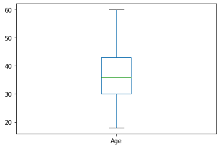

```python
df.boxplot(column = 'Age',
       grid = False,
       figsize = (6,4),
       )

plt.show()
```

```python
iqr = df.Age.quantile(0.75) - df.Age.quantile(0.25)
print("Interquartile range:",iqr)
ub = df.Age.quantile(0.75) + 1.5*iqr
lb = df.Age.quantile(0.25) - 1.5*iqr

print("upper bound:",ub)
print("lower bound:",lb)
```

```
Interquartile range: 13.0
upper bound: 62.5
lower bound: 10.5
```

```python
below_lb = np.sum(df['Age']<10.5)
print("No. of outliers below lower bound:",below_lb)
above_ub = np.sum(df['Age']>62.5)
print("No. of outliers above upper bound:",above_ub)
total_outliers = above_ub + below_lb
print("Total No. of outliers:",total_outliers)
```

```
No. of outliers below lower bound: 0
No. of outliers above upper bound: 0
Total No. of outliers: 0
```

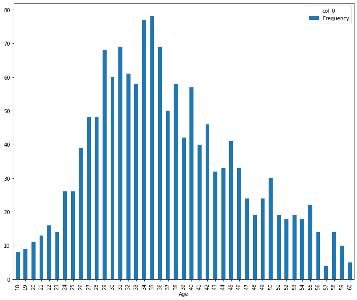

```python
tab.plot(kind='bar', figsize=(12,10))
```

### 3.2 Attrition

```python
tab = pd.crosstab(df.Attrition, columns = 'Frequency')
tab
```

| col_0 Attrition | Frequency |
| --- | --- |
| No | 1233 |
| Yes | 237 |

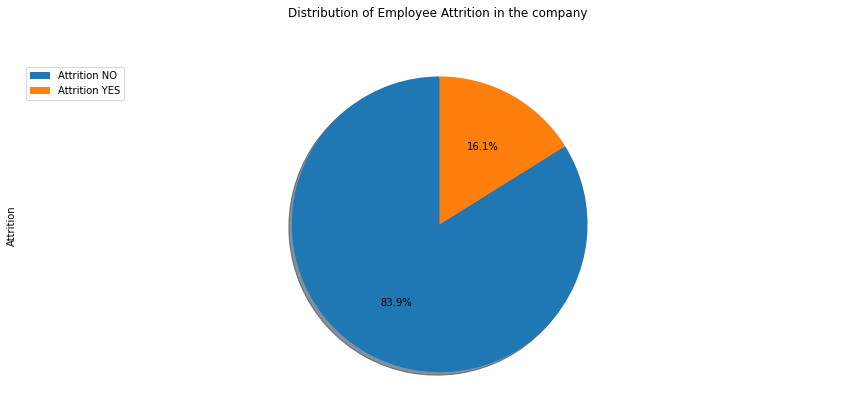

```python
labels = 'Attrition NO', 'Attrition YES'
df['Attrition'].astype(str).value_counts().plot(kind='pie',figsize = (15,6), autopct= '%1.1f%%', startangle= 90, shadow = True, labels = None,)
plt.title('Distribution of Employee Attrition in the company ', y=1.12)
plt.axis('equal')
plt.legend(labels=labels, loc='upper left')
plt.show()
```

#### Observations

- 237 People have left the company
- Attrition rate is 16.1%

## 3.3. Business Travel

```python
tab = pd.crosstab(df.BusinessTravel, columns = 'Frequency')
tab
```

| col_0 BusinessTravel | Frequency |
| --- | --- |
| Non-Travel | 150 |
| Travel_Frequently | 277 |
| Travel_Rarely | 1043 |

**Hypothesis:**

- The majority of the sample consists of individuals who have limited travel experience.

**Observation**

- People doesnt travel much often and account for almost 75%

## 3.4.Deparment

```python
tab = pd.crosstab(df.Department, columns = 'Frequency')
tab
```

| col_0 Department | Frequency |
| --- | --- |
| Human Resources | 63 |
| Research & Development | 961 |
| Sales | 446 |

**Hyposthesis:**

- The sales department has a larger headcount compared to other departments.

**Observation**

- The R & D dept has more employees than any other departments which shows about the nature of the company is "Researh-Oriented".

## 3.5. Education Field

```python
tab = pd.crosstab(df.EducationField, columns = 'Frequency')
tab
```

| col_0 EducationField | Frequency |
| --- | --- |
| Human Resources | 27 |
| Life Sciences | 606 |
| Marketing | 159 |
| Medical | 464 |
| Other | 82 |
| Technical Degree | 132 |

**Hypothesis**

- As the company seems to be research oriented, it should have more people from **Technical background**

*Observation*

- Max number of people are from **Life Sciences** Background and minimum are from **HR**, which shows that the company is research focused more in Life sciences rather than in technical aspects.

## 3.6. Environment Satisfaction

```python
tab = pd.crosstab(df.EnvironmentSatisfaction, columns = 'Frequency')
tab
```

| col_0 EnvironmentSatisfaction | Frequency |
| --- | --- |
| 1 | 284 |
| 2 | 287 |
| 3 | 453 |
| 4 | 446 |

**Hypothesis:**

- People are satisfied as per attrition rate!

**Observation**

- More than 800 people has rated 3 or 4 out of 4 for environment satisfaction, which shows people are satisfied with the working environment.

## 3.7. Gender

```python
tab = pd.crosstab(df.Gender, columns = 'Frequency')
tab
```

| col_0 Gender | Frequency |
| --- | --- |
| Female | 588 |
| Male | 882 |

**Hypothesis:**

- As the company is research oriented, the gender diversity will be unbalanced.

**Observation**

- Female to male ratio is 66.66% and Female accounts for 40% of the sample.

## 3.8. Job Involvement

```python
tab = pd.crosstab(df.JobInvolvement, columns = 'Frequency')
tab
```

| col_0 JobInvolvement | Frequency |
| --- | --- |
| 1 | 83 |
| 2 | 375 |
| 3 | 868 |
| 4 | 144 |

**Hypothesis:**

- Job involvement should be higher as per the company profile.

**Observation**

- More than 900 people finds themselves involved in Job

## 3.9. Job Level

```python
tab = pd.crosstab(df.JobLevel, columns = 'Frequency')
tab
```

| col_0 JobLevel | Frequency |
| --- | --- |
| 1 | 543 |
| 2 | 534 |
| 3 | 218 |
| 4 | 106 |
| 5 | 69 |

**Hypothesis**

- More people should be involved in research and management and top level jobs are less

**Observation**

- More than 1000 People are low level and only 10% are involved in tier 4 or 5 level jobs

## 3.10. Job Satisfacion

```python
tab = pd.crosstab(df.JobSatisfaction, columns = 'Frequency')
tab
```

| col_0 JobSatisfaction | Frequency |
| --- | --- |
| 1 | 289 |
| 2 | 280 |
| 3 | 442 |
| 4 | 459 |

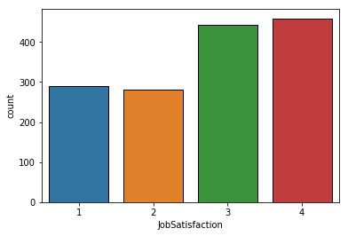

```python
sns.countplot(x='JobSatisfaction', data=df, edgecolor= "Black")
```

**Hypothesis:**

- People are mostly unsatisfied due to imbalance in work life as its a research oriented company.

**Observation**

- Only 289 people are unsatisfied with the job and has rated 1 in Job Satisfaction

## 3.11. Marital Status

```python
tab = pd.crosstab(df.MaritalStatus, columns = 'Frequency')
tab
```

| col_0 MaritalStatus | Frequency |
| --- | --- |
| Divorced | 327 |
| Married | 673 |
| Single | 470 |

**Hypothesis:**

- Most of the people are in R&D hence there should be maximum number of married couples.

**Observation**

- **Married** people account for the maximum of the sample followed by Single and Divorced respectively

## 3.12. Monthly Income

```python
df['MonthlyIncome'].describe()
```

```
count     1470.000000
mean      6502.931293
std       4707.956783
min       1009.000000
25%       2911.000000
50%       4919.000000
75%       8379.000000
max      19999.000000
Name: MonthlyIncome, dtype: float64
```

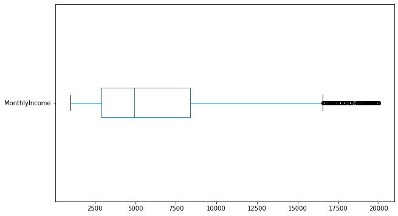

```python
import matplotlib as plt
df.boxplot(column = 'MonthlyIncome',
            grid = False,
            figsize = (10,6),
            vert = False)
```

```python
iqr = df.MonthlyIncome.quantile(0.75) - df.MonthlyIncome.quantile(0.25)
print("Interquartile range:",iqr)
ub = df.MonthlyIncome.quantile(0.75) + 1.5*iqr
lb = df.MonthlyIncome.quantile(0.25) - 1.5*iqr
print("upper bound:",ub)
print("lower bound:",lb)
```

```
Interquartile range: 5468.0
upper bound: 16581.0
lower bound: -5291.0
```

```python
below_lb = np.sum(df['MonthlyIncome']<-5291)
print("No. of outliers below lower bound:",below_lb)
upper_ub = np.sum(df['MonthlyIncome']>16581)
print("No. of outliers above upper bound:",upper_ub)
total_outliers = upper_ub + below_lb
print("Total No. of outliers:",total_outliers)
```

```
No. of outliers below lower bound: 0
No. of outliers above upper bound: 114
Total No. of outliers: 114
```

```
array([[<AxesSubplot:title={'center':'MonthlyIncome'}>]], dtype=object)
```

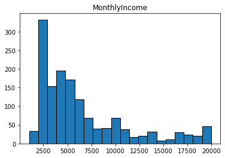

```python
df.hist(column = "MonthlyIncome",
         grid=False,
         figsize = (6,4), bins =20,edgecolor = 'black')
```

**Hypothesis:**

- As the company is research oriented, people are well paid and the mean would lie somewhere around the middle or the data should be left skewed.

**Observation**

- The Monthly income data is right skewed which tells us that mean of the dataset is at the left meaning less income group has more frequency than higher income group.
- The **mean (6502.93)** and **median (4919)** has a huge gap of lumpsum 1500
- Most of the sample **fall below upper quartile**

## 3.13. Overtime

```python
tab = pd.crosstab(df.OverTime, columns = 'Frequency')
tab
```

| col_0 OverTime | Frequency |
| --- | --- |
| No | 1054 |
| Yes | 416 |

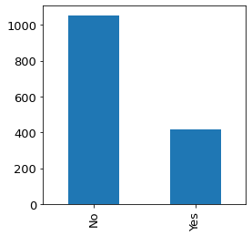

```python
df['OverTime'].value_counts().plot(kind = 'bar', figsize = (4,4),
                                  fontsize =13)
```

**Hypothesis:**

- Looking at the Attrition rate, overtime should be low.

**Observation**

- More than quarter which is **28.29% of the sample works overtime**.

## 3.14. Total working years

```python
df['TotalWorkingYears'].describe()
```

```
count    1470.000000
mean       11.279592
std         7.780782
min         0.000000
25%         6.000000
50%        10.000000
75%        15.000000
max        40.000000
Name: TotalWorkingYears, dtype: float64
```

```python
tab = pd.crosstab(df.TotalWorkingYears, columns='Frequency')
tab
```

| col_0 TotalWorkingYears | Frequency |
| --- | --- |
| 0 | 11 |
| 1 | 81 |
| 2 | 31 |
| 3 | 42 |
| 4 | 63 |
| 5 | 88 |
| 6 | 125 |
| 7 | 81 |
| 8 | 103 |
| 9 | 96 |
| 10 | 202 |
| 11 | 36 |
| 12 | 48 |
| 13 | 36 |
| 14 | 31 |
| 15 | 40 |
| 16 | 37 |
| 17 | 33 |
| 18 | 27 |
| 19 | 22 |
| 20 | 30 |
| 21 | 34 |
| 22 | 21 |
| 23 | 22 |
| 24 | 18 |
| 25 | 14 |
| 26 | 14 |
| 27 | 7 |
| 28 | 14 |
| 29 | 10 |
| 30 | 7 |
| 31 | 9 |
| 32 | 9 |
| 33 | 7 |
| 34 | 5 |
| 35 | 3 |
| 36 | 6 |
| 37 | 4 |
| 38 | 1 |
| 40 | 2 |

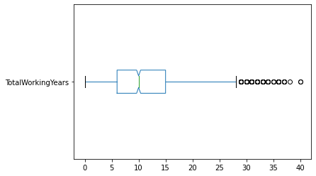

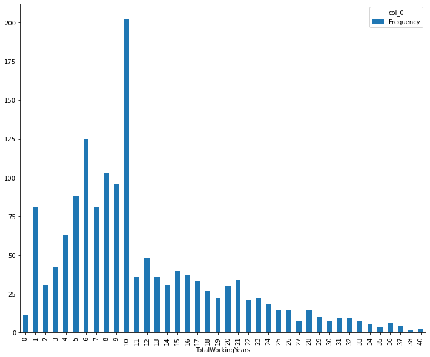

```python
df.boxplot(column= 'TotalWorkingYears',
          grid = False,
          vert = False,
          figsize = (6,4),
          notch = True)

tab.plot(kind='bar',
        figsize = (12,10),
       grid = False)
```

```python
iqr = df.TotalWorkingYears.quantile(0.75) - df.TotalWorkingYears.quantile(0.25)
print("IQR:",iqr)
ub = df.TotalWorkingYears.quantile(0.75) + 1.5*iqr
lb = df.TotalWorkingYears.quantile(0.25) - 1.5*iqr
print("upper bound:",ub)
print("lower bound:",lb)
```

```
IQR: 9.0
upper bound: 28.5
lower bound: -7.5
```

```python
below_lb = np.sum(df['TotalWorkingYears']<lb)
print("No. of outliers below lower bound:",below_lb)
upper_ub = np.sum(df['TotalWorkingYears']>ub)
print("No. of outliers above upper bound:",upper_ub)
total_outliers = below_lb + upper_ub
print("Total no. of outliers:",total_outliers)
```

```
No. of outliers below lower bound: 0
No. of outliers above upper bound: 63
Total no. of outliers: 63
```

**Observation**

## 3.15. Work Life Balance

```python
tab = pd.crosstab(df.WorkLifeBalance, columns = 'Frequency')
tab
```

| col_0 WorkLifeBalance | Frequency |
| --- | --- |
| 1 | 80 |
| 2 | 344 |
| 3 | 893 |
| 4 | 153 |

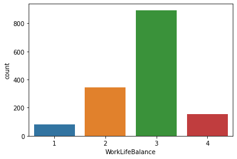

```python
sns.countplot(x = 'WorkLifeBalance', data=df)
```

**Hypothesis:**

- As there is minimal number of people doing overtime, Work life balance should be good.

**Observation**

- Only 80 samples has given rating as 1 and maximum has given 3 as a rating.

## 3.16. Years at Company

```python
df['YearsAtCompany'].describe()
```

```
count    1470.000000
mean        7.008163
std         6.126525
min         0.000000
25%         3.000000
50%         5.000000
75%         9.000000
max        40.000000
Name: YearsAtCompany, dtype: float64
```

```python
tab = pd.crosstab(df.YearsAtCompany, columns='Frequency')
tab
```

| col_0 YearsAtCompany | Frequency |
| --- | --- |
| 0 | 44 |
| 1 | 171 |
| 2 | 127 |
| 3 | 128 |
| 4 | 110 |
| 5 | 196 |
| 6 | 76 |
| 7 | 90 |
| 8 | 80 |
| 9 | 82 |
| 10 | 120 |
| 11 | 32 |
| 12 | 14 |
| 13 | 24 |
| 14 | 18 |
| 15 | 20 |
| 16 | 12 |
| 17 | 9 |
| 18 | 13 |
| 19 | 11 |
| 20 | 27 |
| 21 | 14 |
| 22 | 15 |
| 23 | 2 |
| 24 | 6 |
| 25 | 4 |
| 26 | 4 |
| 27 | 2 |
| 29 | 2 |
| 30 | 1 |
| 31 | 3 |
| 32 | 3 |
| 33 | 5 |
| 34 | 1 |
| 36 | 2 |
| 37 | 1 |
| 40 | 1 |

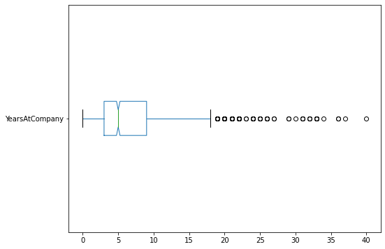

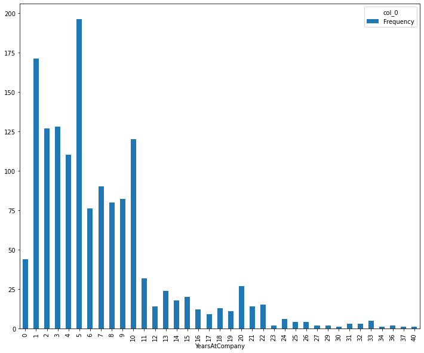

```python
df.boxplot(column = 'YearsAtCompany',
           grid = False,
          vert = False,
          figsize = (8,6),
          notch = True)


tab.plot(kind='bar',
        figsize = (12,10),
       grid = False)
```

```python
iqr = df.YearsAtCompany.quantile(0.75) - df.YearsAtCompany.quantile(0.25)
print("IQR:",iqr)
ub = df.YearsAtCompany.quantile(0.75) + 1.5*iqr
lb = df.YearsAtCompany.quantile(0.25) - 1.5*iqr
print("upper bound:",ub)
print("lower bound:",lb)
```

```
IQR: 6.0
upper bound: 18.0
lower bound: -6.0
```

```python
below_lb = np.sum(df['YearsAtCompany']<lb)
print("No. of outliers below lower bound:",below_lb)
above_ub = np.sum(df['YearsAtCompany']>ub)
print("No. of outliers above upper bound:",above_ub)
total_outliers = above_ub + below_lb
print("Total no. of outliers:",total_outliers)
```

```
No. of outliers below lower bound: 0
No. of outliers above upper bound: 104
Total no. of outliers: 104
```

**Hypothesis**

- Small number of people should be there after the mean.

**Observation**

- **Mean of the sample is 7 years** but there are very few people who has served the company for 40 years.
- The sample is right skewed.

## 3.17. Years in current role

```python
df['YearsInCurrentRole'].describe()
```

```
count    1470.000000
mean        4.229252
std         3.623137
min         0.000000
25%         2.000000
50%         3.000000
75%         7.000000
max        18.000000
Name: YearsInCurrentRole, dtype: float64
```

```python
tab = pd.crosstab(df.YearsInCurrentRole, columns='Frequency')
tab
```

| col_0 YearsInCurrentRole | Frequency |
| --- | --- |
| 0 | 244 |
| 1 | 57 |
| 2 | 372 |
| 3 | 135 |
| 4 | 104 |
| 5 | 36 |
| 6 | 37 |
| 7 | 222 |
| 8 | 89 |
| 9 | 67 |
| 10 | 29 |
| 11 | 22 |
| 12 | 10 |
| 13 | 14 |
| 14 | 11 |
| 15 | 8 |
| 16 | 7 |
| 17 | 4 |
| 18 | 2 |

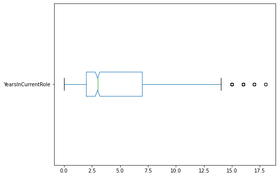

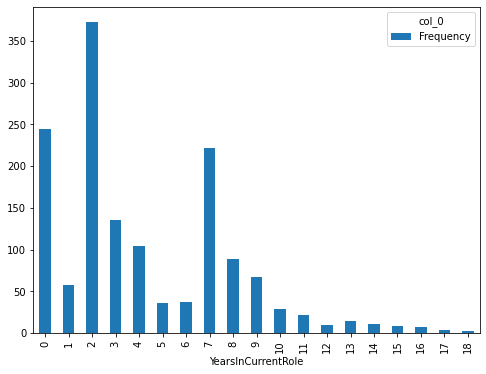

```python
df.boxplot(column = 'YearsInCurrentRole',
           grid = False,
          vert = False,
          figsize = (8,6),
          notch = True)


tab.plot(kind='bar',
        figsize = (8,6),
       grid = False)
```

```python
iqr = df.YearsInCurrentRole.quantile(0.75) - df.YearsInCurrentRole.quantile(0.25)
print("IQR:",iqr)
ub = df.YearsInCurrentRole.quantile(0.75) + 1.5*iqr
lb = df.YearsInCurrentRole.quantile(0.25) - 1.5*iqr

print("upper bound:",ub)
print("lower bound:",lb)
```

```
IQR: 5.0
upper bound: 14.5
lower bound: -5.5
```

```python
below_lb = np.sum(df['YearsInCurrentRole']<lb)
print("No. of outliers below lower bound:",below_lb)
above_ub = np.sum(df['YearsInCurrentRole']>ub)
print("No. of outliers above upper bound:",above_ub)
total_outliers = above_ub + below_lb
print("Total no. of outliers:",total_outliers)
```

```
No. of outliers below lower bound: 0
No. of outliers above upper bound: 21
Total no. of outliers: 21
```

**Hypothesis**

- As the company is onvolved in research, there must be less internal job mobility.

**Observation**

- 50% of the data has 3 years of experience in the current role.
- The sample is right skewed.

## 3.18. Years Since last proportion

```python
df['YearsSinceLastPromotion'].describe()
```

```
count    1470.000000
mean        2.187755
std         3.222430
min         0.000000
25%         0.000000
50%         1.000000
75%         3.000000
max        15.000000
Name: YearsSinceLastPromotion, dtype: float64
```

```python
tab = pd.crosstab(df.YearsSinceLastPromotion, columns='Frequency')
tab
```

| col_0 YearsSinceLastPromotion | Frequency |
| --- | --- |
| 0 | 581 |
| 1 | 357 |
| 2 | 159 |
| 3 | 52 |
| 4 | 61 |
| 5 | 45 |
| 6 | 32 |
| 7 | 76 |
| 8 | 18 |
| 9 | 17 |
| 10 | 6 |
| 11 | 24 |
| 12 | 10 |
| 13 | 10 |
| 14 | 9 |
| 15 | 13 |

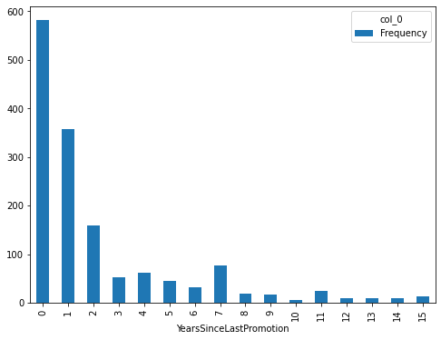

```python
tab.plot(kind='bar', figsize=(8,6))
```

**Hypothesis:**

- Only few people due to performance problem wouldnot be able to get promotion

**Observation**

- There are almost 100 people who had no promotion since last promotion.

## 3.19. Years with current manager

```python
df['YearsWithCurrManager'].describe()
```

```
count    1470.000000
mean        4.123129
std         3.568136
min         0.000000
25%         2.000000
50%         3.000000
75%         7.000000
max        17.000000
Name: YearsWithCurrManager, dtype: float64
```

```python
tab = pd.crosstab(df.YearsWithCurrManager, columns='Frequency')
tab
```

| col_0 YearsWithCurrManager | Frequency |
| --- | --- |
| 0 | 263 |
| 1 | 76 |
| 2 | 344 |
| 3 | 142 |
| 4 | 98 |
| 5 | 31 |
| 6 | 29 |
| 7 | 216 |
| 8 | 107 |
| 9 | 64 |
| 10 | 27 |
| 11 | 22 |
| 12 | 18 |
| 13 | 14 |
| 14 | 5 |
| 15 | 5 |
| 16 | 2 |
| 17 | 7 |

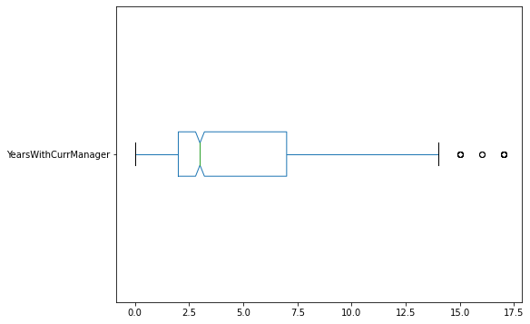

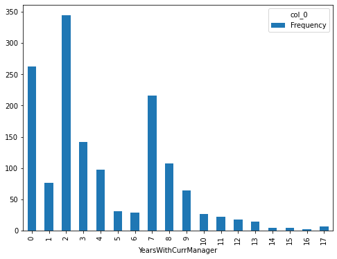

```python
df.boxplot(column = 'YearsWithCurrManager',
          grid = False,
          figsize = (8,6),
          vert = False,
          notch = True)

tab.plot(kind='bar', figsize=(8,6));
```

```python
iqr = df.YearsWithCurrManager.quantile(0.75) - df.YearsWithCurrManager.quantile(0.25)
print("IQR:",iqr)
ub = df.YearsWithCurrManager.quantile(0.75) + 1.5*iqr
lb = df.YearsWithCurrManager.quantile(0.25) - 1.5*iqr
print("upper bound:",ub)
print("lower bound:",lb)
```

```
IQR: 5.0
upper bound: 14.5
lower bound: -5.5
```

```python
below_lb = np.sum(df['YearsWithCurrManager']<lb)
print("No. of outliers below lower bound:",below_lb)
above_ub = np.sum(df['YearsWithCurrManager']>ub)
print("No. of outliers above upper bound:",above_ub)
total_outliers = above_ub + below_lb
print("Total no. of outliers:",total_outliers)
```

```
No. of outliers below lower bound: 0
No. of outliers above upper bound: 14
Total no. of outliers: 14
```

**Hypothesis**

- Since very few people are there who have got no promotion from very long time should be with current manager

**Observation**

- Almost near to 500 People has shown a shift to different managers afte working for 2.5 years.
- Almost 300 people has shown shift to different managers in 0 to 1 year.

## 3.20. Distance from Home

```python
df['DistanceFromHome'].describe()
```

```
count    1470.000000
mean        9.192517
std         8.106864
min         1.000000
25%         2.000000
50%         7.000000
75%        14.000000
max        29.000000
Name: DistanceFromHome, dtype: float64
```

```
array([[<AxesSubplot:title={'center':'DistanceFromHome'}>]], dtype=object)
```

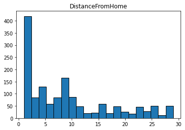

```python
df.hist(column = "DistanceFromHome",
         grid=False,
         figsize = (6,4), bins =20,edgecolor = 'black')
```

**Hypothesis**

- Most People will prefer to live near the company.

**Observation**

# 4. Bivariate Analysis

## 4.1. Age - Attrition

```python
df['Age'].describe()
```

```
count    1470.000000
mean       36.923810
std         9.135373
min        18.000000
25%        30.000000
50%        36.000000
75%        43.000000
max        60.000000
Name: Age, dtype: float64
```

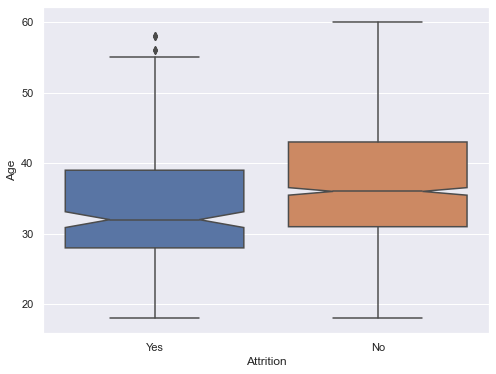

```python
sns.boxplot(x = "Attrition", y = "Age", data=df, notch = True);
```

```python
a=np.quantile(df[df["Attrition"]=='Yes']["Age"],0.25)
b=np.quantile(df[df["Attrition"]=='Yes']["Age"],0.75)

iqr = b-a
print("IQR: ",iqr)

ub = b + 1.5*iqr
lb = a - 1.5*iqr
print("Upper bound: ",ub)
print("Lower bound: ",lb)
```

```
IQR:  11.0
Upper bound:  55.5
Lower bound:  11.5
```

**Hypothesis**

- People who has age less than sample mean tend to leave the company!

**Fact**

- People of all the ages are leaving the company, but people within age 28 to 38 are more prone to leave the company.

## 4.2. Business Travel - Attrition

```python
tab = pd.crosstab(df.Attrition, columns = df.BusinessTravel)
tab
```

| BusinessTravel Attrition | Non-Travel | Travel_Frequently | Travel_Rarely |
| --- | --- | --- | --- |
| No | 138 | 208 | 887 |
| Yes | 12 | 69 | 156 |

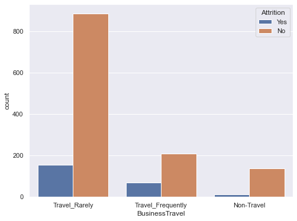

```python
sns.set(rc={'figure.figsize':(8,6)})
sns.countplot(x='BusinessTravel', data=df, hue='Attrition')
```

```python
# Attrition rate:
Non_travel = 12/140
Travel_frequently = 69/(208+69)
Travel_rarely = 156/(156+887)
print("Attrition rate for Non_travel: " , round(Non_travel*100, 2))
print("Attrition rate for Travel_frequently: " ,round(Travel_frequently*100, 2))
print("Attrition rate for Travel_rarely: " , round(Travel_rarely*100, 2))
```

```
Attrition rate for Non_travel:  8.57
Attrition rate for Travel_frequently:  24.91
Attrition rate for Travel_rarely:  14.96
```

**Hypothesis -** Travelling Frequently leads to unbalanced work life which should result in attrition!

**Fact -** We can observe that the attrition rate has prominent connection with Business Travel.

- Highest attrition rate i.e. 24.91% ~ 25% can be observed in the records who travel frequently.

## 4.3. Department - Attrition

```python
tab = pd.crosstab(df.Attrition, columns = df.Department)
tab
```

| Department Attrition | Human Resources | Research & Development | Sales |
| --- | --- | --- | --- |
| No | 51 | 828 | 354 |
| Yes | 12 | 133 | 92 |

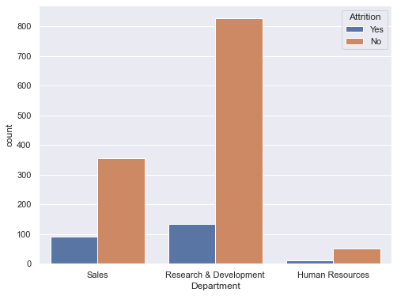

```python
sns.set(rc={'figure.figsize':(8,6)})
sns.countplot(x='Department', data=df, hue='Attrition')
```

```python
print("Attrition rate in Human resources: ", round((12/63)*100,2))
print("Attrition rate in Research & Developement: ", round((133/961)*100,2))
print("Attrition rate in Sales: ", round((12/446)*100,2))
```

[output not shown]

**Hypothesis -** Sales department should have more attrition than any other department due to huge work pressure!

**Fact -** We can observe that the attrition rate has prominent connection with Department.

## 4.4. Environment Satisfaction - Attrition

```python
tab = pd.crosstab(df.Attrition, columns = df.EnvironmentSatisfaction)
tab
```

| EnvironmentSatisfaction Attrition | 1 | 2 | 3 | 4 |
| --- | --- | --- | --- | --- |
| No | 212 | 244 | 391 | 386 |
| Yes | 72 | 43 | 62 | 60 |

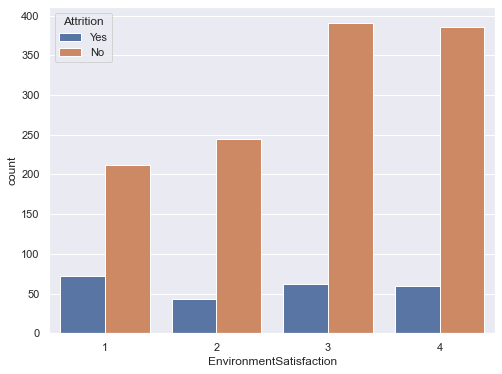

```python
sns.set(rc={'figure.figsize':(8,6)})
sns.countplot(x='EnvironmentSatisfaction', data=df, hue='Attrition')
```

```python
print("Attrition rate for voting 1: ", round((72/284)*100,2))
print("Attrition rate for voting 2: ", round((43/287)*100,2))
print("Attrition rate for voting 3: ", round((62/453)*100,2))
print("Attrition rate for voting 4: ", round((60/446)*100,2))
```

```
Attrition rate for voting 1:  25.35
Attrition rate for voting 2:  14.98
Attrition rate for voting 3:  13.69
Attrition rate for voting 4:  13.45
```

**Hypothesis -** People who has voted 1 for Environment satisfaction are more prone to leaving company!

**Fact -** We can observe that the attrition rate has prominent connection with votings for Environment Satisfaction.

#### Highest attrition rate i.e. **25.35%** can be observed by the people who are dissatisfied with the environment and has voted 1.

## 4.5. Gender - Attrition

```python
tab = pd.crosstab(df.Attrition, columns = df.Gender)
tab
```

| Gender Attrition | Female | Male |
| --- | --- | --- |
| No | 501 | 732 |
| Yes | 87 | 150 |

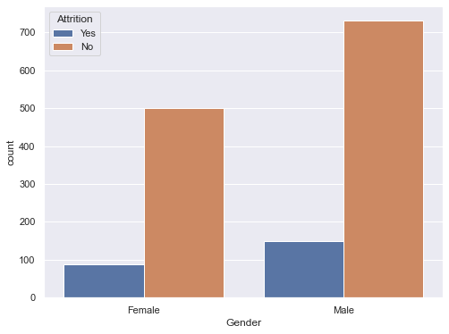

```python
sns.set(rc={'figure.figsize':(8,6)})
sns.countplot(x='Gender', data=df, hue='Attrition')
```

```python
print("Attrition rate for Female: ", round((87/588)*100,2))
print("Attrition rate for Male: ", round((150/732)*100,2))
```

[output not shown]

**Hypothesis -** Male population tends to leave the firm more frequently than Female!

## 4.6. Job Involvement - Attrition

```python
tab = pd.crosstab(df.Attrition, columns = df.JobInvolvement)
tab
```

| JobInvolvement Attrition | 1 | 2 | 3 | 4 |
| --- | --- | --- | --- | --- |
| No | 55 | 304 | 743 | 131 |
| Yes | 28 | 71 | 125 | 13 |

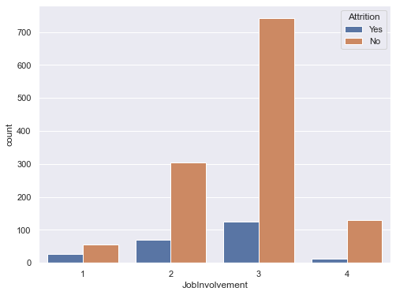

```python
sns.set(rc={'figure.figsize':(8,6)})
sns.countplot(x='JobInvolvement', data=df, hue='Attrition')
```

```python
print("Attrition rate for JI 1: ", round((28/83)*100,2))
print("Attrition rate for JI 2: ", round((71/375)*100,2))
print("Attrition rate for JI 3: ", round((125/868)*100,2))
print("Attrition rate for JI 4: ", round((13/144)*100,2))
```

```
Attrition rate for JI 1:  33.73
Attrition rate for JI 2:  18.93
Attrition rate for JI 3:  14.4
Attrition rate for JI 4:  9.03
```

**Hypothesis -** People who have voted less in the Job Involvement index are more prone to leave the company!

**Fact -** People who have Job involvement index of 1, have an attrition rate of 33.73% which supports the Hypothesis.

## 4.7. Job Level - Attrition

```python
tab = pd.crosstab(df.Attrition, columns = df.JobLevel)
tab
```

| JobLevel Attrition | 1 | 2 | 3 | 4 | 5 |
| --- | --- | --- | --- | --- | --- |
| No | 400 | 482 | 186 | 101 | 64 |
| Yes | 143 | 52 | 32 | 5 | 5 |

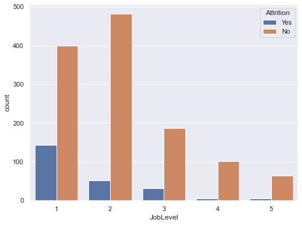

```python
sns.set(rc={'figure.figsize':(8,6)})
sns.countplot(x='JobLevel', data=df, hue='Attrition')
```

```python
print("Attrition rate for JL 1: ", round((143/543)*100,2))
print("Attrition rate for JL 2: ", round((52/534)*100,2))
print("Attrition rate for JL 3: ", round((32/218)*100,2))
print("Attrition rate for JL 4: ", round((5/106)*100,2))
print("Attrition rate for JL 5: ", round((5/69)*100,2))
```

```
Attrition rate for JL 1:  26.34
Attrition rate for JL 2:  9.74
Attrition rate for JL 3:  14.68
Attrition rate for JL 4:  4.72
Attrition rate for JL 5:  7.25
```

**Hypothesis -** People who have lesser Job Level are more prone to leave the company!

**Fact -** People who are involved in Job Level 1 has the highest probability of leaving the job followed by Level 3.

#### Interestingly Job Level 2 people are more stable compared to Job level 3.

## 4.8. Job Satisfaction - Attrition

```python
tab = pd.crosstab(df.Attrition, columns = df.JobSatisfaction)
tab
```

| JobSatisfaction Attrition | 1 | 2 | 3 | 4 |
| --- | --- | --- | --- | --- |
| No | 223 | 234 | 369 | 407 |
| Yes | 66 | 46 | 73 | 52 |

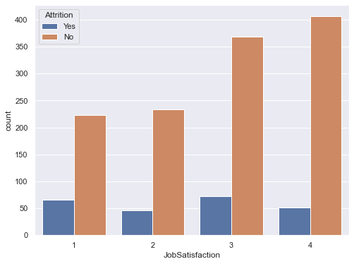

```python
sns.set(rc={'figure.figsize':(8,6)})
sns.countplot(x='JobSatisfaction', data=df, hue='Attrition')
```

```python
print("Attrition rate for voting 1: ", round((66/289)*100,2))
print("Attrition rate for voting 2: ", round((46/280)*100,2))
print("Attrition rate for voting 3: ", round((73/442)*100,2))
print("Attrition rate for voting 4: ", round((52/459)*100,2))
```

```
Attrition rate for voting 1:  22.84
Attrition rate for voting 2:  16.43
Attrition rate for voting 3:  16.52
Attrition rate for voting 4:  11.33
```

**Hypothesis -** People who has voted less in the Job Satisfaction index are more prone to leave the company!

**Fact -** People who have voted 1 in Job Satisfaction has 22.84% chances of leaving the company.

- Interesting fact is that even people who has voted highest in satisfaction index has a chance of 11.33% of leaving the company.

## 4.9. Marital Status - Attrition

```python
tab = pd.crosstab(df.Attrition, columns = df.MaritalStatus)
tab
```

| MaritalStatus Attrition | Divorced | Married | Single |
| --- | --- | --- | --- |
| No | 294 | 589 | 350 |
| Yes | 33 | 84 | 120 |

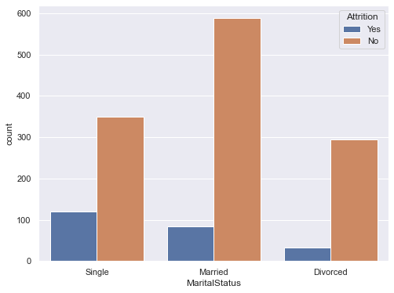

```python
sns.set(rc={'figure.figsize':(8,6)})
sns.countplot(x='MaritalStatus', data=df, hue='Attrition')
```

```python
print("Attrition rate for Divorced: ", round((33/327)*100,2))
print("Attrition rate for Married: ", round((84/673)*100,2))
print("Attrition rate for Single: ", round((120/470)*100,2))
```

```
Attrition rate for Divorced:  10.09
Attrition rate for Married:  12.48
Attrition rate for Single:  25.53
```

**Hypothesis -** People who are single has more attrition rate!

**Fact -** People who are single has more attrition.

- Interesting fact is that Married people are more prone to attrition than divorced people.

## 4.10. Monthly Income - Attrition

```python
df["MonthlyIncome"].describe()
```

```
count     1470.000000
mean      6502.931293
std       4707.956783
min       1009.000000
25%       2911.000000
50%       4919.000000
75%       8379.000000
max      19999.000000
Name: MonthlyIncome, dtype: float64
```

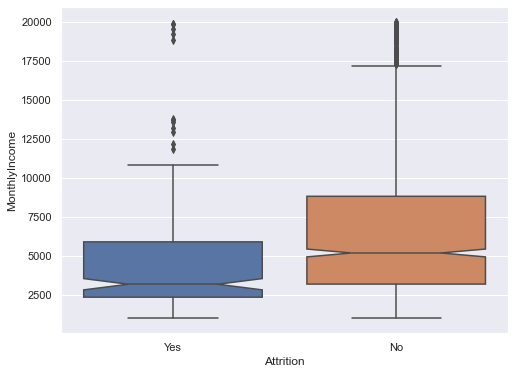

```python
sns.boxplot(x = "Attrition", y = "MonthlyIncome", data=df, notch = True)
```

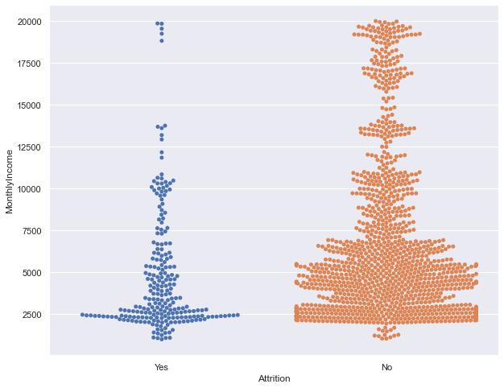

```python
sns.set(rc={'figure.figsize':(10,8)})
sns.swarmplot(x = "Attrition", y = "MonthlyIncome", data=df)
```

```python
a=np.quantile(df[df['Attrition']=='Yes']['MonthlyIncome'],0.25)
b=np.quantile(df[df['Attrition']=='Yes']['MonthlyIncome'],0.75)
iqr = b-a
print("IQR:",iqr)
ub = b + 1.5*iqr
lb = a - 1.5*iqr
print("Upper bound:",ub)
print("Lower bound:",lb)
```

```
IQR: 3543.0
Upper bound: 11230.5
Lower bound: -2941.5
```

**Hypothesis**

- People with low income group,must be leaving the comapany frequently.

**Inferences:**

- We can see in the above plots that the frequency of people leaving the company is more in between 1000 to 2500.